# Tag Prediction on Stack Exchange

2023-10-25

## Problem Description

**Primary objectives:**

This project aims to use data and modeling to explore and predict tags for questions on Stack Exchange.The primary objectives are as follows:

1. Data Extraction
2. Exploratory Data Analysis (EDA)
3. Machine Learning Model Development

[figure not shown]

## Why is it interesting?

1. **Real-world Application**: Improving tag prediction for Stack Exchange and other platforms could benefit millions of users.
2. **Data-Driven Insights**: EDA can reveal user behavior, popular topics, and challenges on Stack Exchange.
3. **Automation**: Automating tag prediction can save time and improve efficiency for moderators and users.
4. **User Experience Improvement**: Accurate tagging improves user engagement by making it easier to find relevant content.

## Analytics Plan - Exploratory Data Analysis

**List of EDA tasks:**

1. Monthly questions count
2. Percentage marked as answered vs. questions
3. Relationships between answers and users
4. Common words/tags in titles
5. Growth or shrinking of particular tags over time

## Methods and Tools

1. **API Integration (httr package)**: httr will be used to interact with APIs and retrieve data for analysis.
2. **Data Visualization (ggplot)**: ggplot will be used to visualize data patterns and model performance.
3. **Machine Learning Libraries (H2O, Keras)**: H2O, Keras and other models will be utilized as the machine learning frameworks.

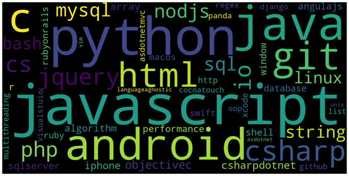

## Evaluation Plan

**Objectives and goals:**

Objective 1: Extract relevant data from the Stack Exchange API.

Objective 2: Conduct exploratory data analysis (EDA).

Objective 3: Develop a machine learning model.

**Key Performance Indicators (KPIs):**

KPI 1: Accuracy

KPI 2: Metrics

KPI 3: Reduction in Manual Tagging